# Projet Visualisation

[Arnaud Frering, Stéfan Baudier, Thomas Rodriguez](https://github.com/ArnaudFrering) - 24 avril 2019

```r
#Chargement des librairies
library(ggplot2)
library(dplyr)
library(gapminder)
library(forcats)
```

## Importation des données

On importe les données des deux csv représentant les performances en termes de points fantasy afin d’en trouver des tendances

```r
#on importe les deux dataframe
data <- read.csv("https://raw.githubusercontent.com/ArnaudFrering/Projet_Visualisation/master/Tableau_Points_Fantasy.csv", header = TRUE, sep = ";")
data2<- read.csv("https://raw.githubusercontent.com/ArnaudFrering/Projet_Visualisation/master/Donnees_boxplot.csv", header = FALSE, sep = ";")


data_boxplot <- as.data.frame(t(data2)) #transposition des lignes en colonnes
data_3 <- as.data.frame(data_boxplot[2:64,c(1,3,8)]) #selection des colonnes Durant Curry et Match sans la 1ere ligne
names(data_3) <- c("Match", "Durant", "Curry") #on renomme les colonnes avec les noms concernés

#on transforme les facteurs en valeur numérique
data_3$"Durant"<-as.numeric(as.character(data_3$"Durant"))
data_3$"Curry"<-as.numeric(as.character(data_3$"Curry"))
data_3$"Match"<-as.numeric(as.character(data_3$"Match"))
```

## Représentation graphique des données

Premièrement nous affichons les dix joueurs ayant les meilleures moyennes de points fantasy, donc ceux qui sont le plus intéressant à jouer dans la fantasy league.

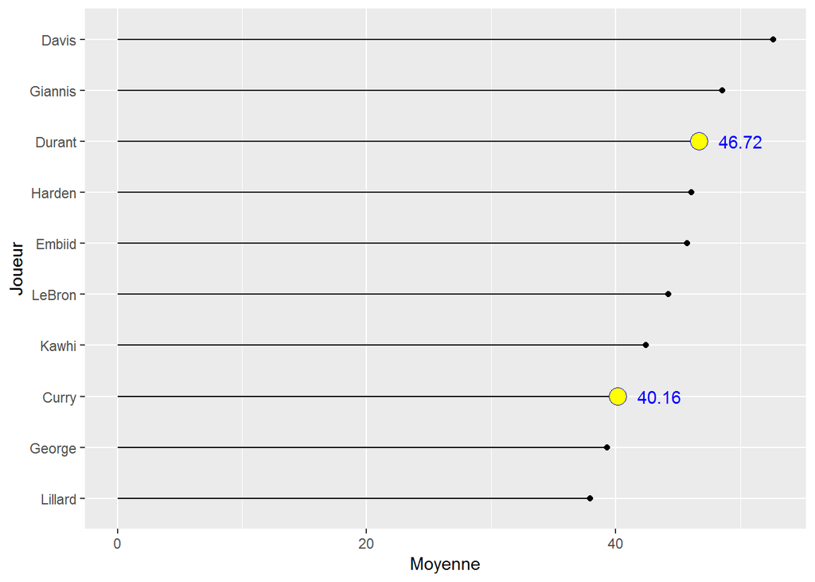

```r
head(data, 10) %>%
  arrange(Moyenne) %>% #on trie suivant la moyenne
  mutate(Joueur=factor(Joueur, Joueur)) %>% #classement par les joueurs en fonction de leur moyenne
  # Création d'un graphique de la moyenne en fonction du joueur
  ggplot(aes( x=Joueur, y=Moyenne )) +
  #on utilise point et segment pour créer un bubble chart
    geom_point()+
    geom_segment(aes( x=Joueur, y=0,  xend=Joueur, yend = Moyenne ),color = "black")+
    coord_flip()+ #on inverse l'axe des abscisses avec celui des ordonnées
  #on met en valeur 2 joueurs de la même équipe
    annotate(geom = "point", x = "Durant", y = 46.72, shape = 21, color = "blue", size = 5, fill = "yellow")+
    annotate(geom = "point", x = "Curry", y = 40.16, shape = 21, color = "blue", size = 5, fill = "yellow")+
  #on affiche leur moyenne
    annotate(geom = "text", x = "Durant", y = 50, label = "46.72", color = "blue") +
    annotate(geom = "text", x = "Curry", y = 43.5, label = "40.16", color = "blue")
```

On remarque que deux des 10 joueurs ayant la meilleure moyenne appartiennent à la même équipe : Kevin Durant et Stephen Curry

On peut se demander comment ses deux joueurs arrivent à créer autant de points fantasy en jouant en même temps.

On choisit donc de représenter leurs performances (venant du deuxième jeu de données) afin de voir si quand l’un des deux joueurs performe, l’autre contre-performe ou si les deux arrivent à faires des grosses performances en même temps

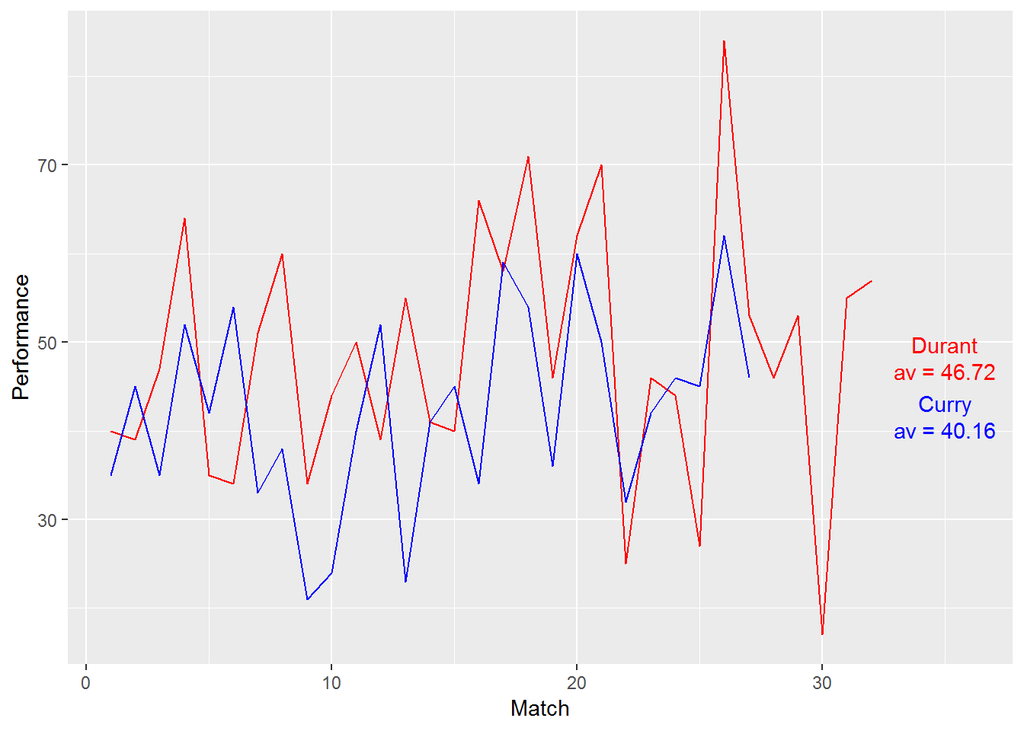

```r
data_3 %>%
  #on affiche 2 courbes sur un même graphique
  ggplot(aes(Match, Durant), ylbl ="Performance") +
  geom_line(color = "red")+
  geom_line(aes(Match, Curry), color = "blue")+
  #association de chaque courbe à un joueur en rappelant la moyenne de chacun
  annotate(geom = "text", x = 35, y = 49.72, label = "Durant", color = "red")+
  annotate(geom = "text", x = 35, y = 46.72, label = "av = 46.72", color = "red")+
  annotate(geom = "text", x = 35, y = 43.16, label = "Curry", color = "blue")+
  annotate(geom = "text", x = 35, y = 40.16, label = "av = 40.16", color = "blue")+
  ylab("Performance")
```

On remarque qu’il n’y a pas de vraie réponse à notre questionnement, et donc que durant certains matchs les deux joueurs arrivent à performer en même temps (comme au match numéro 20 par exemple) et qu’à d’autres occasions les deux ne performent pas en même temps.

On remarque également que durant les derniers matchs enregistrés, Curry n’a pas joué à cause d’une bessure et que c’est durant ces matchs que Durant fait la pire performance de sa saison.

A work by [[Arnaud Frering, Stéfan Baudier, Thomas Rodriguez](https://github.com/ArnaudFrering)](https://github.com/ArnaudFrering)